# Mars function

Author

Guibril Ramde

## Exercise 7.2

```r
#install.packages('kernlab')
library(mlbench)
library(tidyverse)
library(ggplot2)
library(caret)
library(earth)
library(ipred)
library(e1071)
library(kernlab)
#library(randomForest)

set.seed(200)

# Training dataset: 200 observations
trainingData <- mlbench.friedman1(200, sd = 1)
trainingData$x <- as.data.frame(trainingData$x)

# Testing dataset: 5000 observations
testData <- mlbench.friedman1(5000, sd = 1)
testData$x <- as.data.frame(testData$x)

# Exploratory analysis
dim(trainingData$x)
```

```
[1] 200  10
```

```r
summary(trainingData$x)
```

```
       V1                 V2                  V3                 V4
 Min.   :0.002806   Min.   :0.0004409   Min.   :0.003296   Min.   :0.00819
 1st Qu.:0.217222   1st Qu.:0.2795877   1st Qu.:0.284872   1st Qu.:0.23178
 Median :0.513935   Median :0.5106664   Median :0.537307   Median :0.44458
 Mean   :0.481461   Mean   :0.5126936   Mean   :0.508570   Mean   :0.46939
 3rd Qu.:0.680814   3rd Qu.:0.7326078   3rd Qu.:0.746155   3rd Qu.:0.68454
 Max.   :0.998992   Max.   :0.9840194   Max.   :0.999923   Max.   :0.99929
       V5                 V6                 V7                  V8
 Min.   :0.001756   Min.   :0.002901   Min.   :0.0003388   Min.   :0.004698
 1st Qu.:0.285408   1st Qu.:0.276341   1st Qu.:0.2092393   1st Qu.:0.289413
 Median :0.534330   Median :0.497598   Median :0.4688035   Median :0.497961
 Mean   :0.517948   Mean   :0.496841   Mean   :0.4636166   Mean   :0.512865
 3rd Qu.:0.748180   3rd Qu.:0.749616   3rd Qu.:0.6752972   3rd Qu.:0.727624
 Max.   :0.991577   Max.   :0.998987   Max.   :0.9943477   Max.   :0.999561
       V9              V10
 Min.   :0.0176   Min.   :0.003172
 1st Qu.:0.2304   1st Qu.:0.317826
 Median :0.5289   Median :0.535922
 Mean   :0.5016   Mean   :0.542409
 3rd Qu.:0.7218   3rd Qu.:0.789736
 Max.   :0.9910   Max.   :0.999992
```

```r
summary(trainingData$y)
```

```
   Min. 1st Qu.  Median    Mean 3rd Qu.    Max.
  3.556  10.756  14.556  14.416  17.970  28.382
```

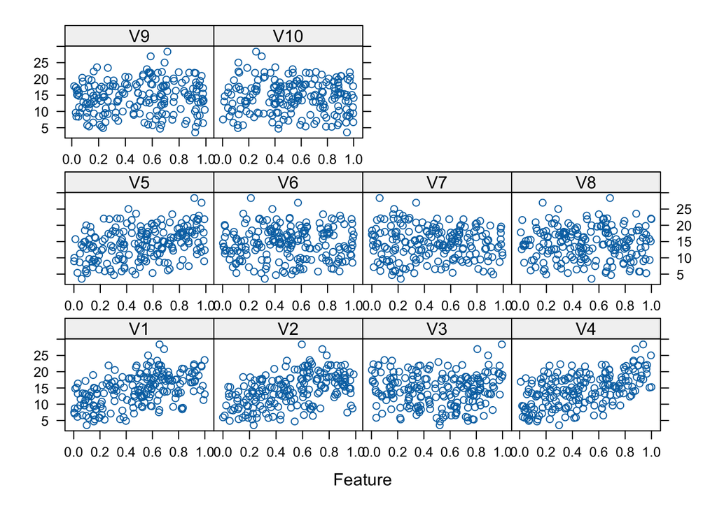

```r
# Examine predictors and response
featurePlot(
  x = trainingData$x,
  y = trainingData$y
)
```

```r
folds <- createFolds(
  trainingData$y,
  k = 10,
  returnTrain = TRUE
)

control <- trainControl(
  method = "cv",
  number = 10,
  index = folds
)
```

```r
# tune several models on these data
set.seed(200)

knnModel <- train(
  x = trainingData$x,
  y = trainingData$y,
  method = "knn",
  preProcess = c("center", "scale"),
  trControl = control,
  tuneLength = 10
)

knnModel
```

```
k-Nearest Neighbors

200 samples
 10 predictor

Pre-processing: centered (10), scaled (10)
Resampling: Cross-Validated (10 fold)
Summary of sample sizes: 180, 180, 180, 180, 180, 180, ...
Resampling results across tuning parameters:

  k   RMSE      Rsquared   MAE
   5  3.288773  0.5889898  2.725944
   7  3.144376  0.6434361  2.577807
   9  3.124264  0.6689980  2.517219
  11  3.077985  0.6915901  2.489324
  13  3.103767  0.7026394  2.506703
  15  3.127439  0.7062228  2.513829
  17  3.149433  0.7114210  2.526318
  19  3.153927  0.7249773  2.528158
  21  3.121909  0.7450302  2.523428
  23  3.171824  0.7389961  2.565383

RMSE was used to select the optimal model using the smallest value.
The final value used for the model was k = 11.
```

```r
# Predictions
knnPred <- predict(
  knnModel,
  newdata = testData$x
)

# Evaluation
postResample(
  pred = knnPred,
  obs = testData$y
)
```

```
     RMSE  Rsquared       MAE
3.1222641 0.6690472 2.4963650
```

```r
set.seed(200)

folds <- createFolds(
  trainingData$y,
  k = 10,
  returnTrain = TRUE
)

control <- trainControl(
  method = "cv",
  number = 10,
  index = folds
)
```

```r
set.seed(200)

marsModel <- train(
  x = trainingData$x,
  y = trainingData$y,
  method = "earth",
  trControl = control,
  tuneGrid = expand.grid(
    nprune = 2:20,
    degree = 1:2
  )
)

marsModel
```

```
Multivariate Adaptive Regression Spline

200 samples
 10 predictor

No pre-processing
Resampling: Cross-Validated (10 fold)
Summary of sample sizes: 180, 180, 180, 180, 180, 180, ...
Resampling results across tuning parameters:

  degree  nprune  RMSE      Rsquared   MAE
  1        2      4.432989  0.2226534  3.6555837
  1        3      3.765358  0.4460270  3.0673378
  1        4      2.614445  0.7244605  2.1232450
  1        5      2.386299  0.7694607  1.9272623
```

[output cut: 37 more lines]

```r
# Predictions
marsPred <- predict(
  marsModel,
  newdata = testData$x
)

# Evaluation
postResample(
  pred = marsPred,
  obs = testData$y
)
```

```
     RMSE  Rsquared       MAE
1.2803060 0.9335241 1.0168673
```

```r
# Variable importance
varImp(marsModel)
```

```
earth variable importance

   Overall
V1  100.00
V4   75.33
V2   48.88
V5   15.63
V3    0.00
```

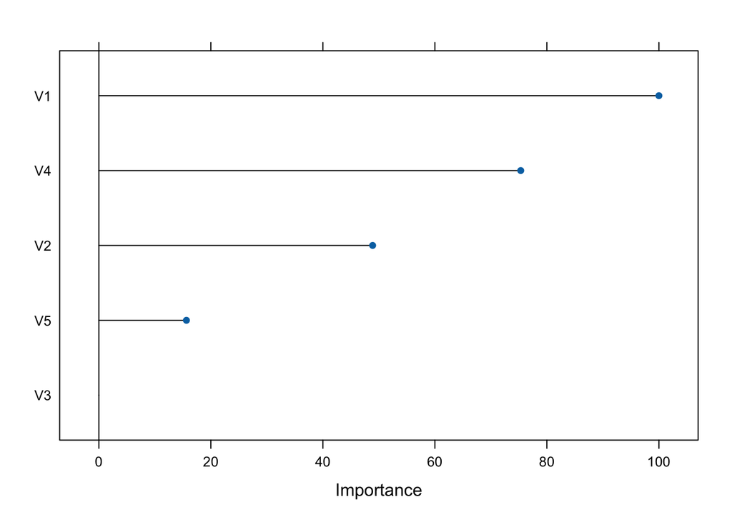

```r
# Plot variable importance
plot(varImp(marsModel))
```

```r
# MARS model summary
summary(marsModel$finalModel)
```

```
Call: earth(x=data.frame[200,10], y=c(18.46,16.1,17...), keepxy=TRUE, degree=2,
            nprune=13)

                                coefficients
(Intercept)                        22.050690
h(0.621722-V1)                    -15.001651
h(V1-0.621722)                     10.878737
h(0.601063-V2)                    -18.830135
h(0.447442-V3)                      9.940077
h(V3-0.606015)                     12.999390
h(0.734892-V4)                     -9.877554
h(V4-0.734892)                     10.414930
h(0.850094-V5)                     -5.604897
h(V1-0.621722) * h(V2-0.295997)   -43.245766
h(0.649253-V1) * h(0.601063-V2)    26.218297

Selected 11 of 18 terms, and 5 of 10 predictors (nprune=13)
Termination condition: Reached nk 21
Importance: V1, V4, V2, V5, V3, V6-unused, V7-unused, V8-unused, V9-unused, ...
Number of terms at each degree of interaction: 1 8 2
GCV 1.747495    RSS 264.5358    GRSq 0.929051    RSq 0.9457576
```

```r
# SVM
set.seed(200)

svmLinearModel <- train(
  x = trainingData$x,
  y = trainingData$y,
  method = "svmLinear",
  preProcess = c("center", "scale"),
  trControl = control,
  tuneLength = 10
)

svmLinearModel
```

```
Support Vector Machines with Linear Kernel

200 samples
 10 predictor

Pre-processing: centered (10), scaled (10)
Resampling: Cross-Validated (10 fold)
Summary of sample sizes: 180, 180, 180, 180, 180, 180, ...
Resampling results:

  RMSE      Rsquared  MAE
  2.432316  0.765497  1.96225

Tuning parameter 'C' was held constant at a value of 1
```

```r
# Predictions
svmLinearPred <- predict(
  svmLinearModel,
  newdata = testData$x
)

postResample(
  pred = svmLinearPred,
  obs = testData$y
)
```

```
     RMSE  Rsquared       MAE
2.7633860 0.6973384 2.0970616
```

```r
set.seed(200)

svmRadialModel <- train(
  x = trainingData$x,
  y = trainingData$y,
  method = "svmRadial",
  preProcess = c("center", "scale"),
  trControl = control,
  tuneLength = 10
)

svmRadialModel
```

```
Support Vector Machines with Radial Basis Function Kernel

200 samples
 10 predictor

Pre-processing: centered (10), scaled (10)
Resampling: Cross-Validated (10 fold)
Summary of sample sizes: 180, 180, 180, 180, 180, 180, ...
Resampling results across tuning parameters:

  C       RMSE      Rsquared   MAE
    0.25  2.502240  0.7991647  1.996420
    0.50  2.251774  0.8122993  1.775708
    1.00  2.071314  0.8353324  1.624308
    2.00  1.954727  0.8525581  1.515420
    4.00  1.884376  0.8615784  1.470561
    8.00  1.861357  0.8643203  1.475030
   16.00  1.852625  0.8668207  1.476040
   32.00  1.852625  0.8668207  1.476040
   64.00  1.852625  0.8668207  1.476040
  128.00  1.852625  0.8668207  1.476040

Tuning parameter 'sigma' was held constant at a value of 0.06299324
RMSE was used to select the optimal model using the smallest value.
The final values used for the model were sigma = 0.06299324 and C = 16.
```

```r
# Predictions
svmRadialPred <- predict(
  svmRadialModel,
  newdata = testData$x
)

postResample(
  pred = svmRadialPred,
  obs = testData$y
)
```

```
     RMSE  Rsquared       MAE
2.0736997 0.8256573 1.5751967
```

```r
#Neural Networks
set.seed(200)

nnetModel <- train(
  x = trainingData$x,
  y = trainingData$y,
  method = "nnet",
  preProcess = c("center", "scale"),
  trControl = control,
  tuneGrid = expand.grid(
    size = c(1, 3, 5, 7, 10),
    decay = c(0, 0.001, 0.01, 0.1)
  ),
  linout = TRUE,
  trace = FALSE,
  maxit = 500,
  MaxNWts = 2000
)

nnetModel
```

```
Neural Network

200 samples
 10 predictor

Pre-processing: centered (10), scaled (10)
Resampling: Cross-Validated (10 fold)
Summary of sample sizes: 180, 180, 180, 180, 180, 180, ...
Resampling results across tuning parameters:

  size  decay  RMSE      Rsquared   MAE
   1    0.000  2.416185  0.7679397  1.890174
   1    0.001  2.414178  0.7683682  1.888124
   1    0.010  2.412928  0.7686759  1.884140
   1    0.100  2.423494  0.7672732  1.888849
   3    0.000  2.441179  0.7796700  1.968065
   3    0.001  2.467861  0.7599315  1.992184
   3    0.010  2.483551  0.7585101  1.981780
   3    0.100  2.425833  0.7733648  1.928426
   5    0.000  2.864127  0.7149238  2.336369
   5    0.001  2.619389  0.7549897  2.046358
   5    0.010  2.577369  0.7424200  2.026045
   5    0.100  2.515321  0.7522710  2.007962
   7    0.000  9.717315  0.4612940  4.641975
   7    0.001  3.342916  0.6048640  2.567427
   7    0.010  2.944651  0.7018668  2.257427
   7    0.100  2.834740  0.7049757  2.232351
  10    0.000  3.623267  0.5962795  2.879838
  10    0.001  3.633105  0.5611956  2.923946
  10    0.010  3.465451  0.5926746  2.834971
  10    0.100  3.001043  0.6955901  2.482799

RMSE was used to select the optimal model using the smallest value.
The final values used for the model were size = 1 and decay = 0.01.
```

```r
# Predictions
nnetPred <- predict(
  nnetModel,
  newdata = testData$x
)

postResample(
  pred = nnetPred,
  obs = testData$y
)
```

```
     RMSE  Rsquared       MAE
2.6433534 0.7194358 2.0232768
```

**##Compare all five models**

```r
# Collect all predictions
predictions <- list(
  KNN = knnPred,
  MARS = marsPred,
  SVM_Linear = svmLinearPred,
  SVM_Radial = svmRadialPred,
  Neural_Network = nnetPred

)

# Calculate evaluation metrics
model_results <- lapply(
  predictions,
  function(pred) {
    postResample(
      pred = pred,
      obs = testData$y
    )
  }
)

# Convert results to a data frame
comparison <- bind_rows(
  model_results,
  .id = "Model"
) |>
  arrange(RMSE)

comparison
```

```
# A tibble: 5 × 4
  Model           RMSE Rsquared   MAE
  <chr>          <dbl>    <dbl> <dbl>
1 MARS            1.28    0.934  1.02
2 SVM_Radial      2.07    0.826  1.58
3 Neural_Network  2.64    0.719  2.02
4 SVM_Linear      2.76    0.697  2.10
5 KNN             3.12    0.669  2.50
```

**##Visualize the models performance**

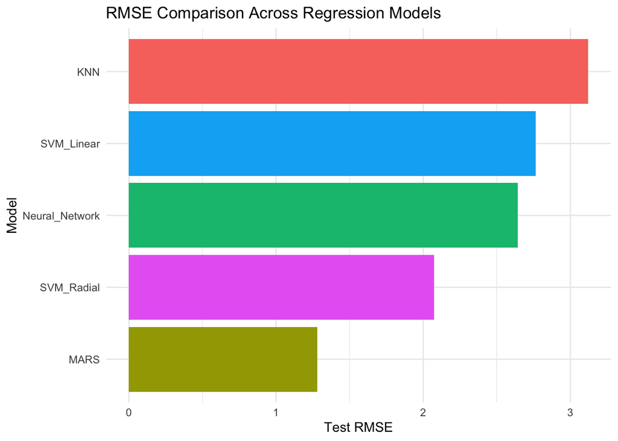

```r
ggplot(
  comparison,
  aes(
    x = reorder(Model, RMSE),
    y = RMSE,
    fill = Model
  )
) +
  geom_col() +
  coord_flip() +
  labs(
    title = "RMSE Comparison Across Regression Models",
    x = "Model",
    y = "Test RMSE"
  ) +
  theme_minimal() +
  theme(legend.position = "none")
```

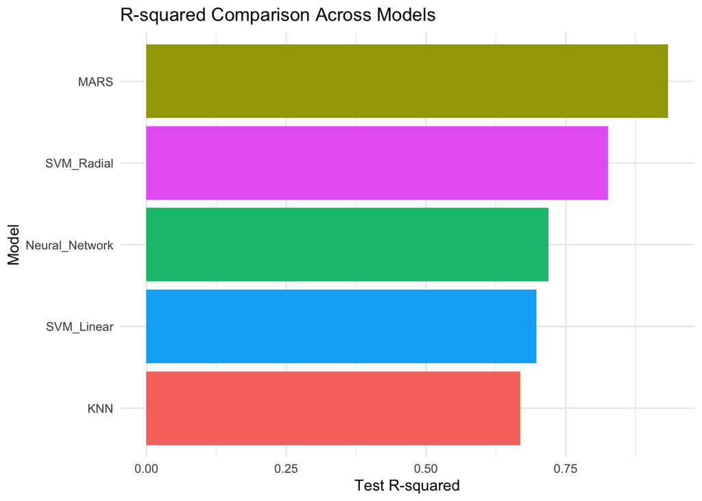

```r
# Visualize the R-square
ggplot(
  comparison,
  aes(
    x = reorder(Model, Rsquared),
    y = Rsquared,
    fill = Model
  )
) +
  geom_col() +
  coord_flip() +
  labs(
    title = "R-squared Comparison Across Models",
    x = "Model",
    y = "Test R-squared"
  ) +
  theme_minimal() +
  theme(legend.position = "none")
```

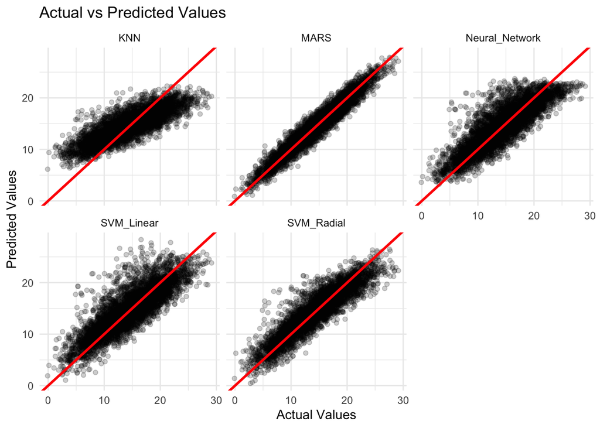

```r
#Comapre the predicted vs the actual
predicted_data <- bind_rows(
  lapply(
    names(predictions),
    function(name) {
      tibble(
        Model = name,
        Actual = testData$y,
        Predicted = predictions[[name]]
      )
    }
  )
)

ggplot(
  predicted_data,
  aes(x = Actual, y = Predicted)
) +
  geom_point(alpha = 0.2) +
  geom_abline(
    slope = 1,
    intercept = 0,
    color = "red",
    linewidth = 1
  ) +
  facet_wrap(~ Model, scales = "fixed") +
  labs(
    title = "Actual vs Predicted Values",
    x = "Actual Values",
    y = "Predicted Values"
  ) +
  theme_minimal()
```

```r
# Best Model
best_model <- comparison |>
  slice_min(
    order_by = RMSE,
    n = 1,
    with_ties = FALSE
  )

best_model
```

```
# A tibble: 1 × 4
  Model  RMSE Rsquared   MAE
  <chr> <dbl>    <dbl> <dbl>
1 MARS   1.28    0.934  1.02
```

### Interpretation

Additionally, the actual versus predicted plot shows that the MARS predictions are closely aligned with the actual values, indicating a good model fit. Since the Friedman dataset contains nonlinear relationships and interactions between predictors, MARS can effectively capture these patterns using piecewise regression functions.

**##Exercise 7.5**

Exercise 6.3 describes data for a chemical manufacturing process. Use the same data imputation, data splitting, and pre-processing steps as before and train several nonlinear regression models.

```r
library(tidyverse)
library(AppliedPredictiveModeling)
library(caret)
library(earth)
library(kernlab)
library(nnet)
set.seed(42)

data(ChemicalManufacturingProcess)

# Dataset exploration
head(ChemicalManufacturingProcess)
```

```
  Yield BiologicalMaterial01 BiologicalMaterial02 BiologicalMaterial03
1 38.00                 6.25                49.58                56.97
2 42.44                 8.01                60.97                67.48
3 42.03                 8.01                60.97                67.48
4 41.42                 8.01                60.97                67.48
5 42.49                 7.47                63.33                72.25
6 43.57                 6.12                58.36                65.31
  BiologicalMaterial04 BiologicalMaterial05 BiologicalMaterial06
1                12.74                19.51                43.73
2                14.65                19.36                53.14
3                14.65                19.36                53.14
4                14.65                19.36                53.14
5                14.02                17.91                54.66
6                15.17                21.79                51.23
  BiologicalMaterial07 BiologicalMaterial08 BiologicalMaterial09
```

[output cut: 118 more lines]

```r
dim(ChemicalManufacturingProcess)
```

```
[1] 176  58
```

```r
str(ChemicalManufacturingProcess)
```

```
'data.frame':   176 obs. of  58 variables:
 $ Yield                 : num  38 42.4 42 41.4 42.5 ...
 $ BiologicalMaterial01  : num  6.25 8.01 8.01 8.01 7.47 6.12 7.48 6.94 6.94 6.94 ...
 $ BiologicalMaterial02  : num  49.6 61 61 61 63.3 ...
 $ BiologicalMaterial03  : num  57 67.5 67.5 67.5 72.2 ...
 $ BiologicalMaterial04  : num  12.7 14.7 14.7 14.7 14 ...
 $ BiologicalMaterial05  : num  19.5 19.4 19.4 19.4 17.9 ...
 $ BiologicalMaterial06  : num  43.7 53.1 53.1 53.1 54.7 ...
 $ BiologicalMaterial07  : num  100 100 100 100 100 100 100 100 100 100 ...
 $ BiologicalMaterial08  : num  16.7 19 19 19 18.2 ...
 $ BiologicalMaterial09  : num  11.4 12.6 12.6 12.6 12.8 ...
 $ BiologicalMaterial10  : num  3.46 3.46 3.46 3.46 3.05 3.78 3.04 3.85 3.85 3.85 ...
 $ BiologicalMaterial11  : num  138 154 154 154 148 ...
 $ BiologicalMaterial12  : num  18.8 21.1 21.1 21.1 21.1 ...
 $ ManufacturingProcess01: num  NA 0 0 0 10.7 12 11.5 12 12 12 ...
```

[output cut: 44 more lines]

```r
summary(ChemicalManufacturingProcess)
```

```
     Yield       BiologicalMaterial01 BiologicalMaterial02 BiologicalMaterial03
 Min.   :35.25   Min.   :4.580        Min.   :46.87        Min.   :56.97
 1st Qu.:38.75   1st Qu.:5.978        1st Qu.:52.68        1st Qu.:64.98
 Median :39.97   Median :6.305        Median :55.09        Median :67.22
 Mean   :40.18   Mean   :6.411        Mean   :55.69        Mean   :67.70
 3rd Qu.:41.48   3rd Qu.:6.870        3rd Qu.:58.74        3rd Qu.:70.43
 Max.   :46.34   Max.   :8.810        Max.   :64.75        Max.   :78.25

 BiologicalMaterial04 BiologicalMaterial05 BiologicalMaterial06
 Min.   : 9.38        Min.   :13.24        Min.   :40.60
 1st Qu.:11.24        1st Qu.:17.23        1st Qu.:46.05
 Median :12.10        Median :18.49        Median :48.46
 Mean   :12.35        Mean   :18.60        Mean   :48.91
 3rd Qu.:13.22        3rd Qu.:19.90        3rd Qu.:51.34
 Max.   :23.09        Max.   :24.85        Max.   :59.38

 BiologicalMaterial07 BiologicalMaterial08 BiologicalMaterial09
 Min.   :100.0        Min.   :15.88        Min.   :11.44
 1st Qu.:100.0        1st Qu.:17.06        1st Qu.:12.60
 Median :100.0        Median :17.51        Median :12.84
 Mean   :100.0        Mean   :17.49        Mean   :12.85
 3rd Qu.:100.0        3rd Qu.:17.88        3rd Qu.:13.13
 Max.   :100.8        Max.   :19.14        Max.   :14.08

 BiologicalMaterial10 BiologicalMaterial11 BiologicalMaterial12
 Min.   :1.770        Min.   :135.8        Min.   :18.35
 1st Qu.:2.460        1st Qu.:143.8        1st Qu.:19.73
 Median :2.710        Median :146.1        Median :20.12
 Mean   :2.801        Mean   :147.0        Mean   :20.20
 3rd Qu.:2.990        3rd Qu.:149.6        3rd Qu.:20.75
 Max.   :6.870        Max.   :158.7        Max.   :22.21

 ManufacturingProcess01 ManufacturingProcess02 ManufacturingProcess03
 Min.   : 0.00          Min.   : 0.00          Min.   :1.47
 1st Qu.:10.80          1st Qu.:19.30          1st Qu.:1.53
 Median :11.40          Median :21.00          Median :1.54
 Mean   :11.21          Mean   :16.68          Mean   :1.54
 3rd Qu.:12.15          3rd Qu.:21.50          3rd Qu.:1.55
 Max.   :14.10          Max.   :22.50          Max.   :1.60
 NA's   :1              NA's   :3              NA's   :15
```

[output cut: 96 more lines]

```
 ManufacturingProcess40 ManufacturingProcess41 ManufacturingProcess42
 Min.   :0.00000        Min.   :0.00000        Min.   : 0.00
 1st Qu.:0.00000        1st Qu.:0.00000        1st Qu.:11.40
 Median :0.00000        Median :0.00000        Median :11.60
 Mean   :0.01771        Mean   :0.02371        Mean   :11.21
 3rd Qu.:0.00000        3rd Qu.:0.00000        3rd Qu.:11.70
 Max.   :0.10000        Max.   :0.20000        Max.   :12.10
 NA's   :1              NA's   :1
 ManufacturingProcess43 ManufacturingProcess44 ManufacturingProcess45
 Min.   : 0.0000        Min.   :0.000          Min.   :0.000
 1st Qu.: 0.6000        1st Qu.:1.800          1st Qu.:2.100
 Median : 0.8000        Median :1.900          Median :2.200
 Mean   : 0.9119        Mean   :1.805          Mean   :2.138
 3rd Qu.: 1.0250        3rd Qu.:1.900          3rd Qu.:2.300
 Max.   :11.0000        Max.   :2.100          Max.   :2.600
```

```r
# Missing values
sum(is.na(ChemicalManufacturingProcess))
```

```
[1] 106
```

```r
colSums(is.na(ChemicalManufacturingProcess))
```

```
                 Yield   BiologicalMaterial01   BiologicalMaterial02
                     0                      0                      0
  BiologicalMaterial03   BiologicalMaterial04   BiologicalMaterial05
                     0                      0                      0
  BiologicalMaterial06   BiologicalMaterial07   BiologicalMaterial08
                     0                      0                      0
  BiologicalMaterial09   BiologicalMaterial10   BiologicalMaterial11
                     0                      0                      0
  BiologicalMaterial12 ManufacturingProcess01 ManufacturingProcess02
                     0                      1                      3
ManufacturingProcess03 ManufacturingProcess04 ManufacturingProcess05
                    15                      1                      1
ManufacturingProcess06 ManufacturingProcess07 ManufacturingProcess08
                     2                      1                      1
ManufacturingProcess09 ManufacturingProcess10 ManufacturingProcess11
                     0                      9                     10
ManufacturingProcess12 ManufacturingProcess13 ManufacturingProcess14
                     1                      0                      1
ManufacturingProcess15 ManufacturingProcess16 ManufacturingProcess17
                     0                      0                      0
ManufacturingProcess18 ManufacturingProcess19 ManufacturingProcess20
                     0                      0                      0
ManufacturingProcess21 ManufacturingProcess22 ManufacturingProcess23
                     0                      1                      1
ManufacturingProcess24 ManufacturingProcess25 ManufacturingProcess26
                     1                      5                      5
ManufacturingProcess27 ManufacturingProcess28 ManufacturingProcess29
                     5                      5                      5
ManufacturingProcess30 ManufacturingProcess31 ManufacturingProcess32
                     5                      5                      0
ManufacturingProcess33 ManufacturingProcess34 ManufacturingProcess35
                     5                      5                      5
ManufacturingProcess36 ManufacturingProcess37 ManufacturingProcess38
                     5                      0                      0
ManufacturingProcess39 ManufacturingProcess40 ManufacturingProcess41
                     0                      1                      1
ManufacturingProcess42 ManufacturingProcess43 ManufacturingProcess44
                     0                      0                      0
ManufacturingProcess45
                     0
```

**##Exploratory data analysis**

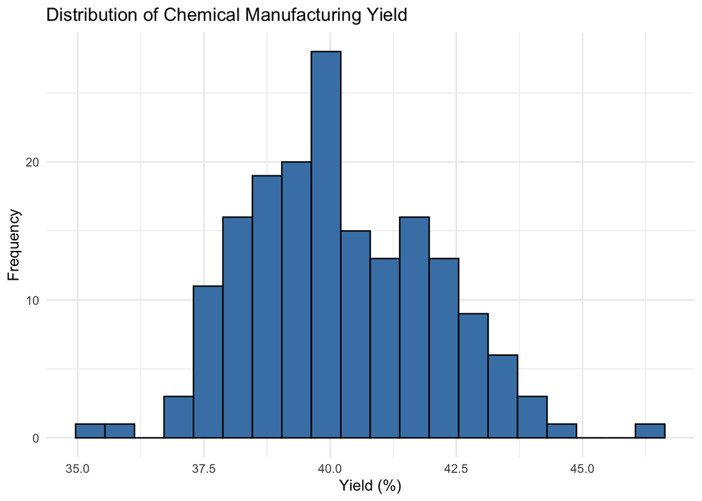

```r
yield_plot <- ggplot(
  ChemicalManufacturingProcess,
  aes(x = Yield)
) +
  geom_histogram(
    bins = 20,
    fill = "steelblue",
    color = "black"
  ) +
  labs(
    title = "Distribution of Chemical Manufacturing Yield",
    x = "Yield (%)",
    y = "Frequency"
  ) +
  theme_minimal()

print(yield_plot)
```

```r
ggsave(
  "MARS_yield_distribution.png",
  yield_plot,
  width = 9,
  height = 5.5,
  dpi = 300
)

# Missing values by predictor
missing_by_variable <- sort(
  colSums(is.na(ChemicalManufacturingProcess)),
  decreasing = TRUE
)

head(missing_by_variable, 15)
```

```
ManufacturingProcess03 ManufacturingProcess11 ManufacturingProcess10
                    15                     10                      9
ManufacturingProcess25 ManufacturingProcess26 ManufacturingProcess27
                     5                      5                      5
ManufacturingProcess28 ManufacturingProcess29 ManufacturingProcess30
                     5                      5                      5
ManufacturingProcess31 ManufacturingProcess33 ManufacturingProcess34
                     5                      5                      5
ManufacturingProcess35 ManufacturingProcess36 ManufacturingProcess02
                     5                      5                      3
```

```r
# Remove observations with missing response
model_data <- ChemicalManufacturingProcess |>
  filter(!is.na(Yield))

set.seed(42)

train_index <- createDataPartition(
  model_data$Yield,
  p = 0.80,
  list = FALSE
)

train_data <- model_data[train_index, , drop = FALSE]
test_data <- model_data[-train_index, , drop = FALSE]

# Preprocessing
preprocess_model <- preProcess(
  train_data |> select(-Yield),
  method = c("medianImpute", "center", "scale")
)

x_train <- predict(
  preprocess_model,
  train_data |> select(-Yield)
)

x_test <- predict(
  preprocess_model,
  test_data |> select(-Yield)
)

train_processed <- bind_cols(
  tibble(Yield = train_data$Yield),
  as_tibble(x_train)
)

test_processed <- bind_cols(
  tibble(Yield = test_data$Yield),
  as_tibble(x_test)
)

# Check results
dim(train_processed)
```

```
[1] 144  58
```

```r
dim(test_processed)
```

```
[1] 32 58
```

```r
sum(is.na(train_processed))
```

```
[1] 0
```

```r
sum(is.na(test_processed))
```

```
[1] 0
```

```r
set.seed(42)

folds <- createFolds(
  train_processed$Yield,
  k = 10,
  returnTrain = TRUE
)

control <- trainControl(
  method = "cv",
  number = 10,
  index = folds
)
```

```r
set.seed(42)

knnModel <- train(
  Yield ~ .,
  data = train_processed,
  method = "knn",
  trControl = control,
  tuneLength = 10
)

knnModel
```

```
k-Nearest Neighbors

144 samples
 57 predictor

No pre-processing
Resampling: Cross-Validated (10 fold)
Summary of sample sizes: 128, 129, 130, 130, 128, 130, ...
Resampling results across tuning parameters:

  k   RMSE      Rsquared   MAE
   5  1.244040  0.5408253  1.023276
   7  1.312593  0.4873704  1.080397
   9  1.364263  0.4542507  1.124819
  11  1.359890  0.4711554  1.126593
  13  1.365952  0.4563463  1.127534
  15  1.372466  0.4542979  1.137705
  17  1.394964  0.4353030  1.150754
  19  1.411442  0.4158501  1.161529
  21  1.410953  0.4260760  1.161424
  23  1.432978  0.4096841  1.172731

RMSE was used to select the optimal model using the smallest value.
The final value used for the model was k = 5.
```

```r
# Predictions
knnPred <- predict(
  knnModel,
  newdata = test_processed
)

# Evaluation
postResample(
  pred = knnPred,
  obs = test_processed$Yield
)
```

```
     RMSE  Rsquared       MAE
1.3738785 0.5488151 0.9719375
```

```r
# Mars model
set.seed(42)

marsModel <- train(
  Yield ~ .,
  data = train_processed,
  method = "earth",
  trControl = control,
  tuneGrid = expand.grid(
    nprune = 2:20,
    degree = 1:2
  )
)

marsModel
```

```
Multivariate Adaptive Regression Spline

144 samples
 57 predictor

No pre-processing
Resampling: Cross-Validated (10 fold)
Summary of sample sizes: 128, 129, 130, 130, 128, 130, ...
Resampling results across tuning parameters:

  degree  nprune  RMSE      Rsquared   MAE
  1        2      1.430727  0.3826690  1.1191546
  1        3      1.355812  0.4697185  1.0828022
  1        4      1.226361  0.5543103  0.9786656
  1        5      1.278567  0.5265214  1.0103382
```

[output cut: 37 more lines]

```r
# Predictions
marsPred <- predict(
  marsModel,
  newdata = test_processed
)

# Evaluation
postResample(
  pred = marsPred,
  obs = test_processed$Yield
)
```

```
     RMSE  Rsquared       MAE
1.4248559 0.5534361 1.0203994
```

```r
# Final model
summary(marsModel$finalModel)
```

```
Call: earth(x=matrix[144,57], y=c(38,42.44,42.0...), keepxy=TRUE, degree=2,
            nprune=9)

                                                                           coefficients
(Intercept)                                                                   38.046565
h(-1.14897-ManufacturingProcess09)                                            -1.100176
h(ManufacturingProcess09- -1.14897)                                            0.872789
h(ManufacturingProcess32- -1.2965)                                             0.727688
h(ManufacturingProcess01- -0.830301) * h(-0.245576-ManufacturingProcess33)     0.559615
h(ManufacturingProcess04- -0.592305) * h(ManufacturingProcess32- -1.2965)      0.667772
h(ManufacturingProcess04- -0.275671) * h(ManufacturingProcess39-0.0172987)    -3.770619
h(0.273211-ManufacturingProcess06) * h(ManufacturingProcess09- -1.14897)      -0.825138
h(-0.410521-ManufacturingProcess17) * h(ManufacturingProcess39-0.0172987)      7.981566

Selected 9 of 54 terms, and 8 of 57 predictors (nprune=9)
Termination condition: GRSq -10 at 54 terms
Importance: ManufacturingProcess32, ManufacturingProcess09, ...
Number of terms at each degree of interaction: 1 3 5
GCV 0.8822112    RSS 92.68732    GRSq 0.7322299    RSq 0.8018928
```

```r
# Coefficients
coef(marsModel$finalModel)
```

```
                                                               (Intercept)
                                                                38.0465653
                                        h(ManufacturingProcess32- -1.2965)
                                                                 0.7276875
                                       h(ManufacturingProcess09- -1.14897)
                                                                 0.8727894
                                        h(-1.14897-ManufacturingProcess09)
                                                                -1.1001756
  h(0.273211-ManufacturingProcess06) * h(ManufacturingProcess09- -1.14897)
                                                                -0.8251380
 h(-0.410521-ManufacturingProcess17) * h(ManufacturingProcess39-0.0172987)
                                                                 7.9815657
 h(ManufacturingProcess04- -0.592305) * h(ManufacturingProcess32- -1.2965)
                                                                 0.6677719
h(ManufacturingProcess04- -0.275671) * h(ManufacturingProcess39-0.0172987)
                                                                -3.7706190
h(ManufacturingProcess01- -0.830301) * h(-0.245576-ManufacturingProcess33)
                                                                 0.5596154
```

```r
# Variable importance
mars_importance <- varImp(marsModel)

mars_importance
```

```
earth variable importance

                       Overall
ManufacturingProcess32  100.00
ManufacturingProcess09   64.82
ManufacturingProcess06   34.04
ManufacturingProcess17   27.75
ManufacturingProcess39   27.75
ManufacturingProcess04   21.71
ManufacturingProcess01    0.00
ManufacturingProcess33    0.00
```

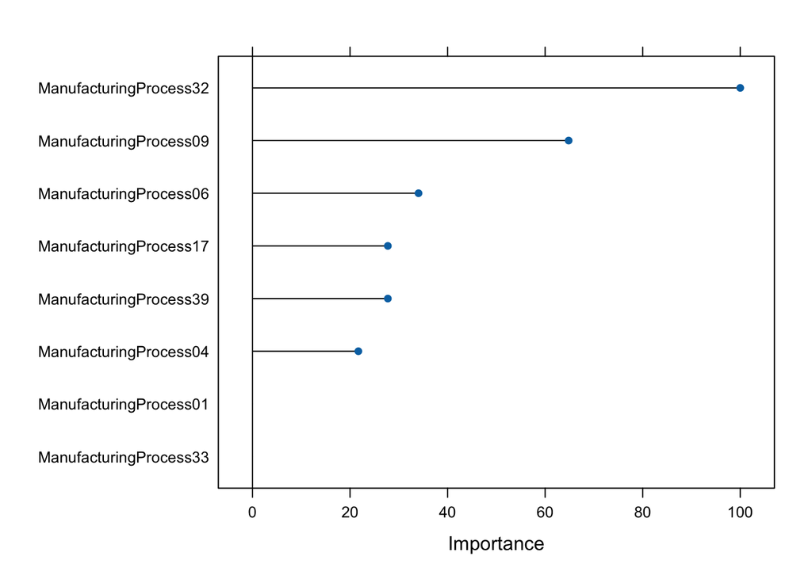

```r
plot(mars_importance)
```

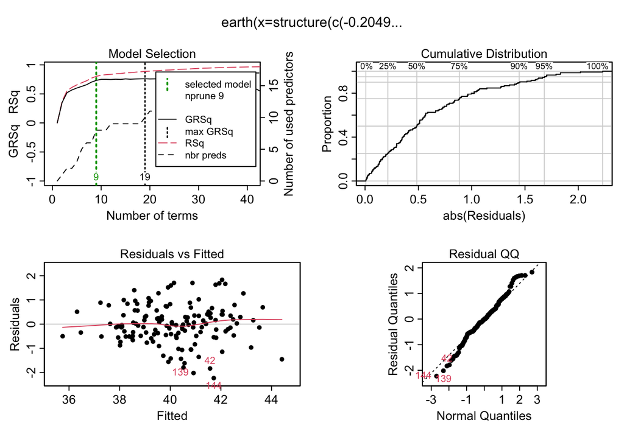

```r
# MARS diagnostic plots
plot(marsModel$finalModel)
```

```r
# SVM
set.seed(42)

svmLinearModel <- train(
  Yield ~ .,
  data = train_processed,
  method = "svmLinear",
  trControl = control,
  tuneLength = 10
)

svmLinearModel
```

```
Support Vector Machines with Linear Kernel

144 samples
 57 predictor

No pre-processing
Resampling: Cross-Validated (10 fold)
Summary of sample sizes: 128, 129, 130, 130, 128, 130, ...
Resampling results:

  RMSE      Rsquared   MAE
  3.713475  0.4705089  1.810233

Tuning parameter 'C' was held constant at a value of 1
```

```r
# Predictions
svmLinearPred <- predict(
  svmLinearModel,
  newdata = test_processed
)

postResample(
  pred = svmLinearPred,
  obs = test_processed$Yield
)
```

```
     RMSE  Rsquared       MAE
1.2425622 0.6171401 0.9491937
```

```r
#SVM Radial
set.seed(42)

svmRadialModel <- train(
  Yield ~ .,
  data = train_processed,
  method = "svmRadial",
  trControl = control,
  tuneLength = 10
)

svmRadialModel
```

```
Support Vector Machines with Radial Basis Function Kernel

144 samples
 57 predictor

No pre-processing
Resampling: Cross-Validated (10 fold)
Summary of sample sizes: 128, 129, 130, 130, 128, 130, ...
Resampling results across tuning parameters:

  C       RMSE      Rsquared   MAE
    0.25  1.397369  0.4977627  1.1448942
    0.50  1.278128  0.5399648  1.0482201
    1.00  1.176753  0.5939419  0.9543719
    2.00  1.135787  0.6124316  0.9064516
    4.00  1.127997  0.6215421  0.9030751
    8.00  1.108598  0.6364725  0.8916759
   16.00  1.107539  0.6378048  0.8910765
   32.00  1.107539  0.6378048  0.8910765
   64.00  1.107539  0.6378048  0.8910765
  128.00  1.107539  0.6378048  0.8910765

Tuning parameter 'sigma' was held constant at a value of 0.01489089
RMSE was used to select the optimal model using the smallest value.
The final values used for the model were sigma = 0.01489089 and C = 16.
```

```r
# Predictions
svmRadialPred <- predict(
  svmRadialModel,
  newdata = test_processed
)

postResample(
  pred = svmRadialPred,
  obs = test_processed$Yield
)
```

```
     RMSE  Rsquared       MAE
1.2884031 0.6073312 0.9405254
```

```r
# Neural Networks Model
set.seed(42)

nnetModel <- train(
  Yield ~ .,
  data = train_processed,
  method = "nnet",
  trControl = control,
  tuneGrid = expand.grid(
    size = c(1, 3, 5, 7, 10),
    decay = c(0, 0.001, 0.01, 0.1)
  ),
  linout = TRUE,
  trace = FALSE,
  maxit = 500,
  MaxNWts = 2000
)

nnetModel
```

```
Neural Network

144 samples
 57 predictor

No pre-processing
Resampling: Cross-Validated (10 fold)
Summary of sample sizes: 128, 129, 130, 130, 128, 130, ...
Resampling results across tuning parameters:

  size  decay  RMSE      Rsquared    MAE
   1    0.000  1.668605  0.20669650  1.348523
   1    0.001  1.648740  0.35994255  1.334224
   1    0.010  1.752132  0.31605341  1.397902
   1    0.100  1.661771  0.35372605  1.340637
   3    0.000  2.758737  0.20032773  2.125011
   3    0.001  2.653715  0.30761720  1.909724
   3    0.010  2.819903  0.21490586  2.136095
   3    0.100  3.088103  0.24953583  2.201376
   5    0.000  3.830514  0.14943312  2.974661
   5    0.001  3.260636  0.09846871  2.341122
   5    0.010  2.894665  0.31676335  2.187823
   5    0.100  2.767204  0.26741379  1.962434
   7    0.000  4.460707  0.16485850  3.328479
   7    0.001  2.920082  0.28792203  2.141823
   7    0.010  2.878847  0.23615515  2.161221
   7    0.100  3.171473  0.20632423  2.144890
  10    0.000  7.893853  0.06685100  4.971657
  10    0.001  6.268534  0.13864805  4.522672
  10    0.010  4.476432  0.15236623  3.130031
  10    0.100  2.802354  0.25052049  2.091162

RMSE was used to select the optimal model using the smallest value.
The final values used for the model were size = 1 and decay = 0.001.
```

```r
# Predictions
nnetPred <- predict(
  nnetModel,
  newdata = test_processed
)

postResample(
  pred = nnetPred,
  obs = test_processed$Yield
)
```

```
     RMSE  Rsquared       MAE
1.2259036 0.6448059 0.9553021
```

**##Compare all five**

```r
# Store predictions
predictions <- list(
  KNN = knnPred,
  MARS = marsPred,
  SVM_Linear = svmLinearPred,
  SVM_Radial = svmRadialPred,
  Neural_Network = nnetPred

)

# Calculate performance metrics
model_results <- lapply(
  predictions,
  function(pred) {
    postResample(
      pred = pred,
      obs = test_processed$Yield
    )
  }
)

# Create comparison table
comparison <- bind_rows(
  model_results,
  .id = "Model"
) |>
  arrange(RMSE)

comparison
```

```
# A tibble: 5 × 4
  Model           RMSE Rsquared   MAE
  <chr>          <dbl>    <dbl> <dbl>
1 Neural_Network  1.23    0.645 0.955
2 SVM_Linear      1.24    0.617 0.949
3 SVM_Radial      1.29    0.607 0.941
4 KNN             1.37    0.549 0.972
5 MARS            1.42    0.553 1.02
```

**##Visualize model performance**

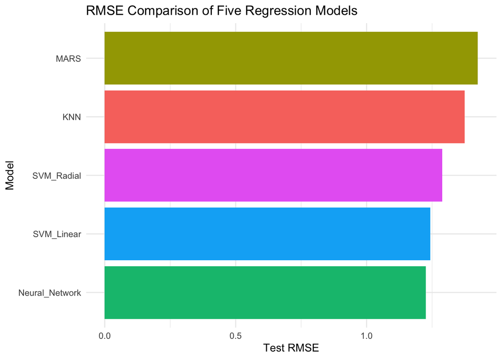

```r
ggplot(
  comparison,
  aes(
    x = reorder(Model, RMSE),
    y = RMSE,
    fill = Model
  )
) +
  geom_col() +
  coord_flip() +
  labs(
    title = "RMSE Comparison of Five Regression Models",
    x = "Model",
    y = "Test RMSE"
  ) +
  theme_minimal() +
  theme(legend.position = "none")
```

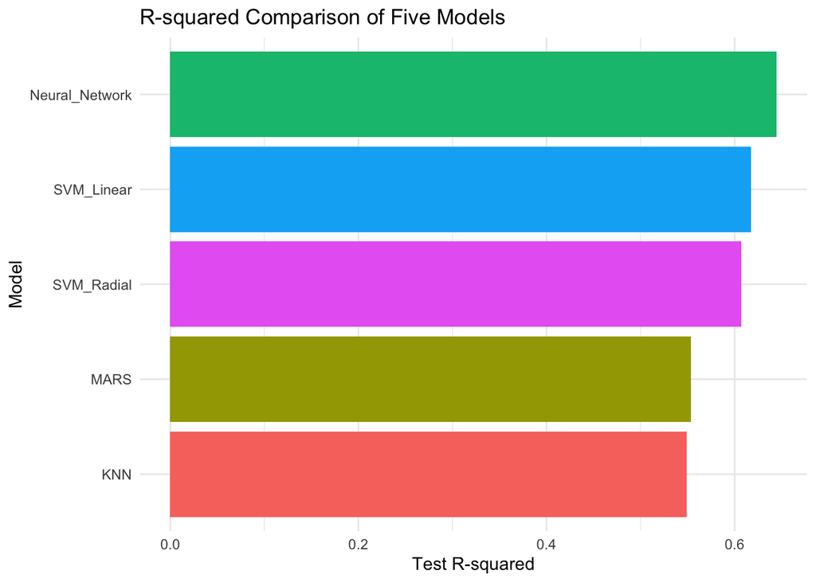

```r
ggplot(
  comparison,
  aes(
    x = reorder(Model, Rsquared),
    y = Rsquared,
    fill = Model
  )
) +
  geom_col() +
  coord_flip() +
  labs(
    title = "R-squared Comparison of Five Models",
    x = "Model",
    y = "Test R-squared"
  ) +
  theme_minimal() +
  theme(legend.position = "none")
```

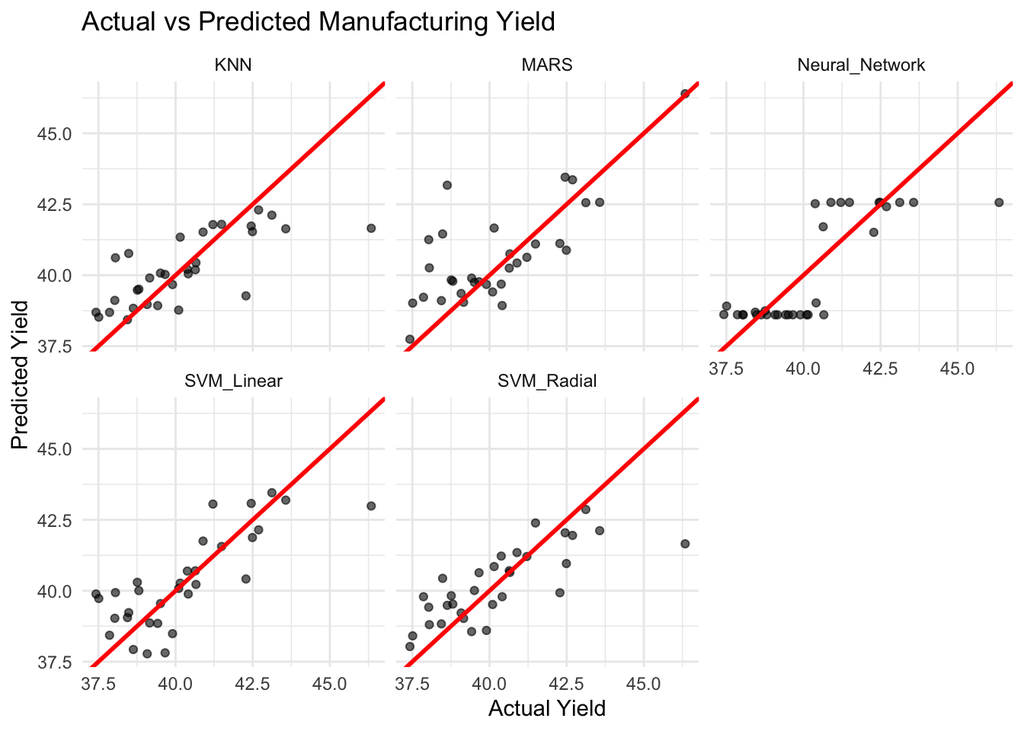

```r
predicted_data <- bind_rows(
  lapply(
    names(predictions),
    function(name) {
      tibble(
        Model = name,
        Actual = test_processed$Yield,
        Predicted = predictions[[name]]
      )
    }
  )
)

ggplot(
  predicted_data,
  aes(x = Actual, y = Predicted)
) +
  geom_point(alpha = 0.6) +
  geom_abline(
    slope = 1,
    intercept = 0,
    color = "red",
    linewidth = 1
  ) +
  facet_wrap(~ Model) +
  labs(
    title = "Actual vs Predicted Manufacturing Yield",
    x = "Actual Yield",
    y = "Predicted Yield"
  ) +
  theme_minimal()
```

**##Compare cross-validation**

```r
model_resamples <- resamples(
  list(
    KNN = knnModel,
    MARS = marsModel,
    SVM_Linear = svmLinearModel,
    SVM_Radial = svmRadialModel,
    Neural_Network = nnetModel

  )
)

summary(model_resamples)
```

```
Call:
summary.resamples(object = model_resamples)

Models: KNN, MARS, SVM_Linear, SVM_Radial, Neural_Network
Number of resamples: 10

MAE
                    Min.   1st Qu.    Median      Mean  3rd Qu.     Max. NA's
KNN            0.7346667 0.9422054 1.0523214 1.0232762 1.122676 1.184714    0
MARS           0.4940149 0.6900834 0.8515230 0.8741773 1.020462 1.296867    0
SVM_Linear     0.6800268 0.9847195 1.1429465 1.8102335 1.266112 8.347196    0
SVM_Radial     0.5597241 0.7363036 0.8353486 0.8910765 0.970552 1.352390    0
Neural_Network 0.8638228 1.1318587 1.3061836 1.3342240 1.585045 1.882866    0

RMSE
                    Min.   1st Qu.   Median     Mean  3rd Qu.      Max. NA's
KNN            1.0317044 1.1116954 1.308224 1.244040 1.344813  1.423410    0
MARS           0.7240758 0.8792829 1.045028 1.118314 1.230480  1.720611    0
SVM_Linear     0.8261778 1.1847316 1.349527 3.713475 1.647619 25.196369    0
SVM_Radial     0.8033869 0.9383318 1.086007 1.107539 1.197420  1.620343    0
Neural_Network 1.0879501 1.3085580 1.691832 1.648740 1.977086  2.163170    0

Rsquared
                      Min.   1st Qu.    Median      Mean   3rd Qu.      Max.
KNN            0.325974137 0.4497631 0.4848883 0.5408253 0.6880081 0.8062443
MARS           0.360329627 0.5849356 0.6789879 0.6457536 0.7434353 0.8452116
SVM_Linear     0.006677735 0.3463312 0.4765197 0.4705089 0.6331664 0.8455222
SVM_Radial     0.250318787 0.6004521 0.6730952 0.6378048 0.7608339 0.7971990
Neural_Network 0.046691351 0.1806138 0.3787999 0.3599425 0.5653289 0.6687371
               NA's
KNN               0
MARS              0
SVM_Linear        0
SVM_Radial        0
Neural_Network    0
```

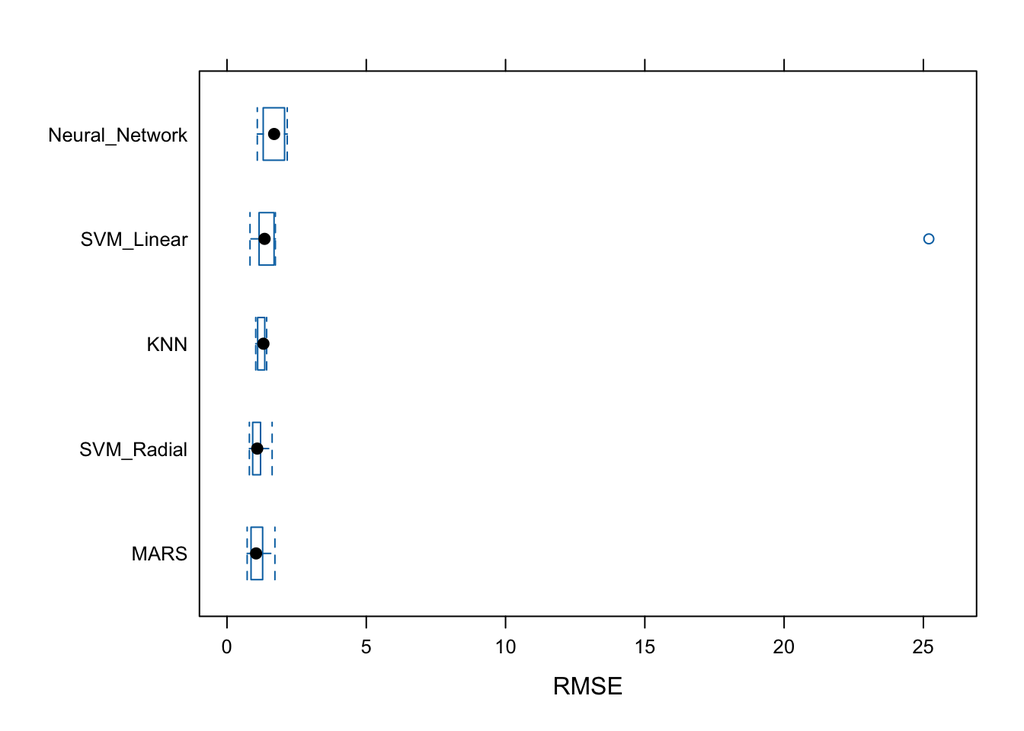

```r
bwplot(
  model_resamples,
  metric = "RMSE"
)
```

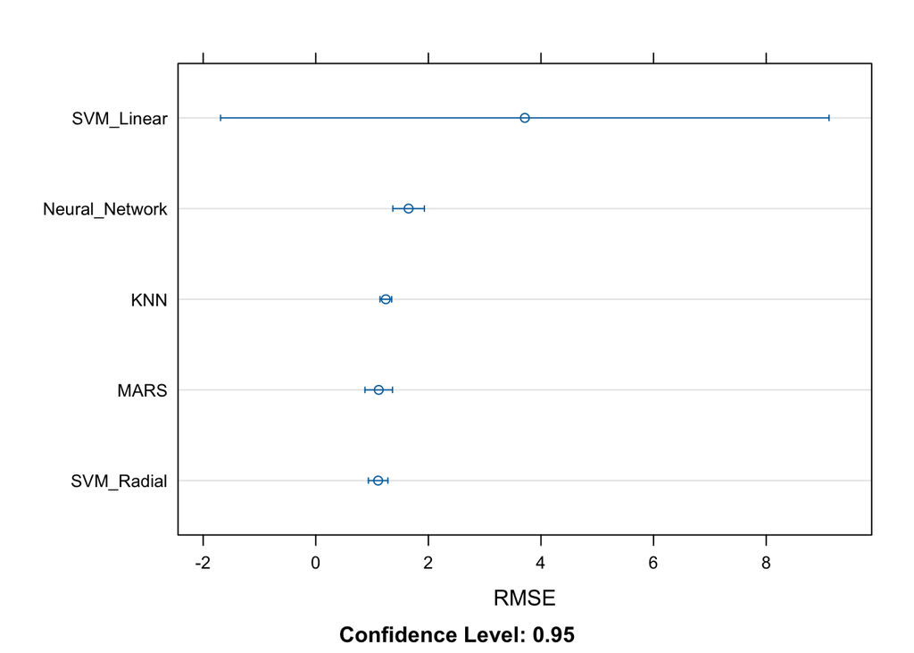

```r
dotplot(
  model_resamples,
  metric = "RMSE"
)
```

```r
# Exclude linear SVM from nonlinear model selection
nonlinear_comparison <- comparison |>
  filter(Model != "SVM_Linear") |>
  arrange(RMSE)

nonlinear_comparison
```

```
# A tibble: 4 × 4
  Model           RMSE Rsquared   MAE
  <chr>          <dbl>    <dbl> <dbl>
1 Neural_Network  1.23    0.645 0.955
2 SVM_Radial      1.29    0.607 0.941
3 KNN             1.37    0.549 0.972
4 MARS            1.42    0.553 1.02
```

```r
# Best nonlinear model
best_nonlinear <- nonlinear_comparison |>
  slice(1)

best_nonlinear
```

```
# A tibble: 1 × 4
  Model           RMSE Rsquared   MAE
  <chr>          <dbl>    <dbl> <dbl>
1 Neural_Network  1.23    0.645 0.955
```

```r
# Best cross-validation RMSE for each nonlinear model
cv_results <- bind_rows(
  lapply(
    list(
      KNN = knnModel,
      MARS = marsModel,
      SVM_Radial = svmRadialModel,
      Neural_Network = nnetModel

    ),
    function(model) {
      model$results |>
        slice_min(RMSE, n = 1, with_ties = FALSE) |>
        select(RMSE, Rsquared, MAE)
    }
  ),
  .id = "Model"
) |>
  arrange(RMSE)

cv_results
```

```
           Model     RMSE  Rsquared       MAE
1     SVM_Radial 1.107539 0.6378048 0.8910765
2           MARS 1.118314 0.6457536 0.8741773
3            KNN 1.244040 0.5408253 1.0232762
4 Neural_Network 1.648740 0.3599425 1.3342240
```

### (a) Optimal Nonlinear Regression Model

Four nonlinear regression models were evaluated to predict chemical manufacturing yield: KNN, MARS, SVM Radial, and Neural Network. SVM Linear was also included for comparison.

The models were trained using 10-fold cross-validation and evaluated on an independent test dataset.

Based on cross-validation performance, SVM Radial achieved the lowest RMSE of 1.1075, followed closely by MARS with an RMSE of 1.1183. KNN and Neural Network produced higher cross-validation errors.

However, on the independent test dataset, Neural Network achieved the lowest RMSE of 1.2259, with an R-squared of 0.6448 and an MAE of 0.9553.

These results indicate that the best-performing model depends on the evaluation method. SVM Radial performed best during cross-validation, while Neural Network performed best on the test dataset.

Therefore, SVM Radial was selected as the optimal nonlinear regression model based on cross-validation RMSE, with Neural Network providing the strongest test-set performance.

**b. Which predictors are most important**

```r
library(caret)
library(dplyr)
library(ggplot2)

set.seed(42)

# Training predictors and response
x_train <- train_processed |>
  select(-Yield)

y_train <- train_processed$Yield

# Original predictions
original_pred <- predict(
  svmRadialModel,
  newdata = x_train
)

# Original RMSE
original_rmse <- RMSE(original_pred, y_train)

# Calculate permutation importance
permutation_importance <- function(model, data, response, nsim = 10) {

  baseline_pred <- predict(model, newdata = data)
  baseline_rmse <- RMSE(baseline_pred, response)

  importance <- sapply(names(data), function(variable) {

    rmse_values <- replicate(nsim, {

      permuted_data <- data

      # Shuffle one predictor
      permuted_data[[variable]] <- sample(
        permuted_data[[variable]]
      )

      # Predict with shuffled data
      permuted_pred <- predict(
        model,
        newdata = permuted_data
      )

      RMSE(permuted_pred, response) - baseline_rmse
    })

    mean(rmse_values)
  })

  data.frame(
    Variable = names(importance),
    Importance = as.numeric(importance)
  ) |>
    arrange(desc(Importance))
}

# permutation importance
set.seed(42)

svm_importance <- permutation_importance(
  model = svmRadialModel,
  data = train_processed |> select(-Yield),
  response = train_processed$Yield,
  nsim = 30
)

top10_nonlinear <- svm_importance |>
  slice_head(n = 10)

top10_nonlinear
```

```
                 Variable Importance
1  ManufacturingProcess32  0.6264861
2  ManufacturingProcess36  0.3298613
3  ManufacturingProcess09  0.2937248
4  ManufacturingProcess37  0.2843384
5  ManufacturingProcess13  0.2823769
6  ManufacturingProcess28  0.2441497
7  ManufacturingProcess11  0.2411713
8    BiologicalMaterial03  0.2379343
9  ManufacturingProcess38  0.2293577
10 ManufacturingProcess17  0.2237996
```

```r
top10_nonlinear <- svm_importance |>
  slice_head(n = 10)

top10_nonlinear
```

```
                 Variable Importance
1  ManufacturingProcess32  0.6264861
2  ManufacturingProcess36  0.3298613
3  ManufacturingProcess09  0.2937248
4  ManufacturingProcess37  0.2843384
5  ManufacturingProcess13  0.2823769
6  ManufacturingProcess28  0.2441497
7  ManufacturingProcess11  0.2411713
8    BiologicalMaterial03  0.2379343
9  ManufacturingProcess38  0.2293577
10 ManufacturingProcess17  0.2237996
```

```r
# Biological predictors
biological_vars <- names(
  ChemicalManufacturingProcess
)[2:13]

top10_nonlinear <- top10_nonlinear |>
  mutate(
    Variable_Type = if_else(
      Variable %in% biological_vars,
      "Biological",
      "Process"
    )
  )

top10_nonlinear
```

```
                 Variable Importance Variable_Type
1  ManufacturingProcess32  0.6264861       Process
2  ManufacturingProcess36  0.3298613       Process
3  ManufacturingProcess09  0.2937248       Process
4  ManufacturingProcess37  0.2843384       Process
5  ManufacturingProcess13  0.2823769       Process
6  ManufacturingProcess28  0.2441497       Process
7  ManufacturingProcess11  0.2411713       Process
8    BiologicalMaterial03  0.2379343    Biological
9  ManufacturingProcess38  0.2293577       Process
10 ManufacturingProcess17  0.2237996       Process
```

```r
# Count biological vs process
top10_nonlinear |>
  count(Variable_Type)
```

```
  Variable_Type n
1    Biological 1
2       Process 9
```

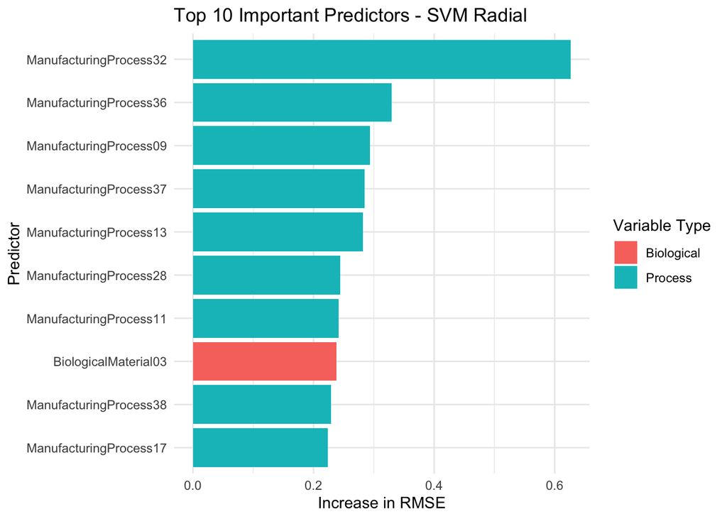

```r
ggplot(
  top10_nonlinear,
  aes(
    x = reorder(Variable, Importance),
    y = Importance,
    fill = Variable_Type
  )
) +
  geom_col() +
  coord_flip() +
  labs(
    title = "Top 10 Important Predictors - SVM Radial",
    x = "Predictor",
    y = "Increase in RMSE",
    fill = "Variable Type"
  ) +
  theme_minimal()
```

```r
# Import Ridge results from Exercise 6.3
top10_linear <- read.csv("ridge_top10.csv")

top10_linear
```

```
                Predictor   Overall
1  ManufacturingProcess32 100.00000
2  ManufacturingProcess09  78.88595
3  ManufacturingProcess36  71.51112
4  ManufacturingProcess13  70.37738
5  ManufacturingProcess17  68.25682
6  ManufacturingProcess34  54.47594
7  ManufacturingProcess06  45.69522
8  ManufacturingProcess11  43.90333
9    BiologicalMaterial03  40.71388
10 ManufacturingProcess33  40.21446
```

```r
# Predictors shared by both models
common_predictors <- intersect(
  top10_nonlinear$Variable,
  top10_linear$Predictor
)

common_predictors
```

```
[1] "ManufacturingProcess32" "ManufacturingProcess36" "ManufacturingProcess09"
[4] "ManufacturingProcess13" "ManufacturingProcess11" "BiologicalMaterial03"
[7] "ManufacturingProcess17"
```

```r
# Predictors unique to SVM Radial
unique_nonlinear <- setdiff(
  top10_nonlinear$Variable,
  top10_linear$Predictor
)

unique_nonlinear
```

```
[1] "ManufacturingProcess37" "ManufacturingProcess28" "ManufacturingProcess38"
```

```r
# Predictors unique to Ridge
unique_linear <- setdiff(
  top10_linear$Predictor,
  top10_nonlinear$Variable
)

unique_linear
```

```
[1] "ManufacturingProcess34" "ManufacturingProcess06" "ManufacturingProcess33"
```

```r
# Predictors shared by both models
common_predictors <- intersect(
  top10_nonlinear$Variable,
  top10_linear$Predictor
)

common_predictors
```

```
[1] "ManufacturingProcess32" "ManufacturingProcess36" "ManufacturingProcess09"
[4] "ManufacturingProcess13" "ManufacturingProcess11" "BiologicalMaterial03"
[7] "ManufacturingProcess17"
```

```r
# Predictors unique to SVM Radial
unique_nonlinear <- setdiff(
  top10_nonlinear$Variable,
  top10_linear$Predictor
)

unique_nonlinear
```

```
[1] "ManufacturingProcess37" "ManufacturingProcess28" "ManufacturingProcess38"
```

```r
# Predictors unique to linear model
unique_linear <- setdiff(
  top10_linear$Predictor,
  top10_nonlinear$Variable
)

unique_linear
```

```
[1] "ManufacturingProcess34" "ManufacturingProcess06" "ManufacturingProcess33"
```

### (b) Important Predictors

Permutation importance was used to identify the ten most influential predictors in the SVM Radial model.

ManufacturingProcess32 was the most important predictor, with an increase in RMSE of approximately 0.6265 when its values were randomly shuffled. ManufacturingProcess36 and ManufacturingProcess09 followed, with increases in RMSE of approximately 0.3299 and 0.2937, respectively.

Among the ten most important predictors, nine were manufacturing process variables and one was a biological material variable (BiologicalMaterial03).

These results suggest that manufacturing process variables contribute substantially to the SVM Radial model’s predictive performance. However, variable importance does not necessarily indicate a causal relationship with manufacturing yield.

**c. Explore the relationships between the top predictors and the response for the predictors that are unique to the optimal nonlinear regression model. Do these plots reveal intuition about the biological or process predictors and their relationship with yield?**

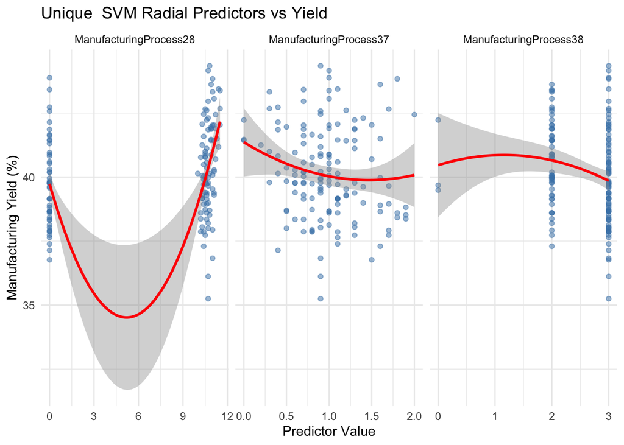

```r
# Plot predictors unique to the nonlinear model
plot_data <- train_data |>
  select(Yield, all_of(unique_nonlinear)) |>
  pivot_longer(
    cols = all_of(unique_nonlinear),
    names_to = "Predictor",
    values_to = "Value"
  ) |>
  filter(!is.na(Value), !is.na(Yield))

ggplot(
  plot_data,
  aes(x = Value, y = Yield)
) +
  geom_point(
    alpha = 0.5,
    color = "steelblue"
  ) +
  geom_smooth(
    method = "lm",
    formula = y ~ x + I(x^2),
    se = TRUE,
    color = "red"
  ) +
  facet_wrap(
    ~ Predictor,
    scales = "free_x"
  ) +
  labs(
    title = "Unique  SVM Radial Predictors vs Yield",
    x = "Predictor Value",
    y = "Manufacturing Yield (%)"
  ) +
  theme_minimal()
```

### (c) Relationships Between Unique Nonlinear Predictors and Yield

The relationships between manufacturing yield and three predictors appearing in the SVM Radial model’s top-ten importance list, but not in the Ridge model’s top-ten list, were examined using scatterplots and quadratic regression curves.

ManufacturingProcess28 shows a potentially nonlinear relationship with yield. However, observations are concentrated in two distinct groups, making it difficult to determine the relationship between them. The wide confidence interval indicates substantial uncertainty in the fitted curve.

ManufacturingProcess37 shows a slight decrease in yield as its value increases, followed by a relatively stable relationship. However, the observations are widely scattered, suggesting a weak individual association with yield.

ManufacturingProcess38 shows a slight curved relationship, but most observations are concentrated at values of 2 and 3. Therefore, the evidence for a nonlinear relationship is limited.

Overall, these plots suggest that some manufacturing process predictors may have nonlinear associations with yield. However, the relationships are not sufficiently strong or consistent to establish clear nonlinear effects. The results also suggest that relationships between manufacturing process variables and yield may be more complex than those captured by simple individual predictor plots.